# a3_task4_james_gately

James Gately

10/30/2020

## Summary

This markdown file completes the fourth of four assigned tasks for ESM 206 Assignment 3. In it, I wrangle urchin data gathered by the SBC LTER program (which can be found [HERE](https://sbclter.msi.ucsb.edu/data/catalog/package/?package=knb-lter-sbc.26)) and do some exploratory data visualization for purple urchin test sizes measured at Naples Reef, Santa Barbara during January 2010. Test diameters were measured under two treatments: control (where no giant kelp was removed) and annual (annual kelp removal conducted). I conclude with a statistical analysis of the data subset.

### Read in SBC LTER urchin data

```r
urchins <- read_csv(here::here("data", "urchins.csv")) %>%
  clean_names()

# Note: here::here used due to here() conflict between here::here and lubridate::here
```

### Wrangle urchin data

```r
# Only keep purple urchin data from NAPL reef, January 2010
napl_jan_2010 <- urchins %>%
  mutate(date = mdy(date)) %>%
  mutate(month = month(date)) %>%
  mutate(year = year(date)) %>%
  filter(site == "NAPL",
         common_name == "Purple Urchin",
         month == 1,
         year == 2010)
```

### Exploratory data visualization

In this subsection, I will do some exploratory data visualization using histograms and quantile-quantile plots. The goal of this section is to evaluate the normality of purple urchin test size data obtained from Naples Reef, Santa Barbara in January 2010.

##### Histogram:

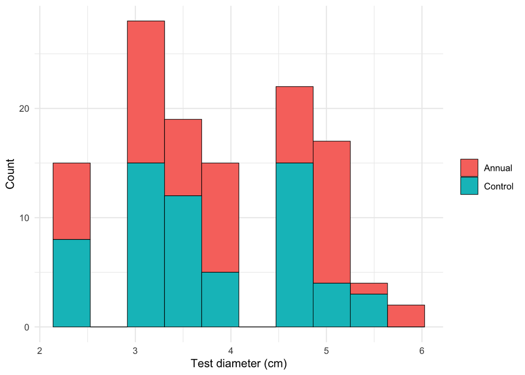

```r
ggplot(data = napl_jan_2010, aes(x = size, fill = treatment)) +
  geom_histogram(bins = 10, color = "black", size = .25) +
  theme_minimal() +
  labs(x = "Test diameter (cm)", y = "Count") +
  scale_fill_discrete(name = NULL, labels = c("Annual", "Control"))
```

#### QQ-plot:

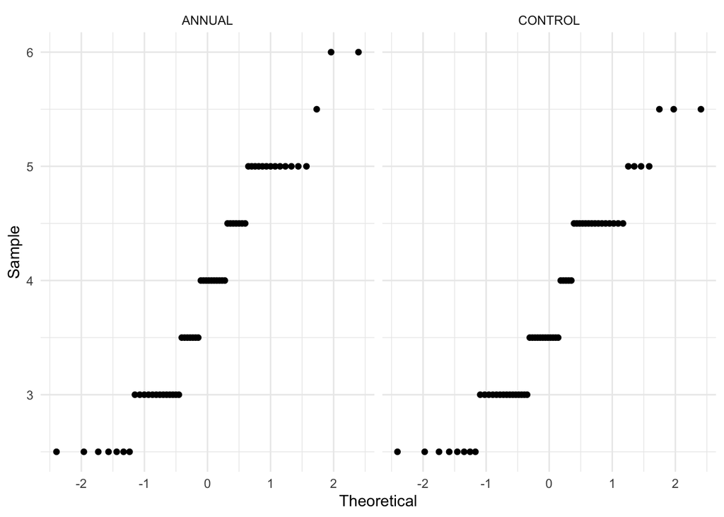

```r
  ggplot(data = napl_jan_2010, aes(sample = size)) +
  geom_qq() +
  theme_minimal() +
  facet_wrap(~treatment) +
  labs(x = "Theoretical", y = "Sample")
```

#### Main takeaways:

From the exploratory graphs above, the urchin samples appear to be normally distributed. Although we do have some empty bins in our histogram, a pattern of normalcy is evident. We also observe that the qq-plots are relatively linear, although we do see a bit of a plateau on the ends of the controls. Based on these visualizations, and applying the Central Limit Theorem based on the large sample size (n > 30), we can assume a normal distribution with relative confidence and analyze our means using a two-sample t-test.

### Statistical analysis

Here, I create a table of summary statistics for purple urchin data collected from Naples Reef, Santa Barbara (January 2010) and perform a two-sample t-test.

#### Summary statistics:

```r
# Calculate statistics
napl_jan_2010_stats <- napl_jan_2010 %>%
  group_by(common_name, treatment) %>%
  summarise(mean = mean(size),
            sd = sd(size),
            n = n()) %>%
  mutate(treatment = case_when(
    treatment == "CONTROL" ~ "Control",
    treatment == "ANNUAL" ~ "Annual"))

# Create a clean looking graph
kable(napl_jan_2010_stats,
      col.names = c("Common name",
                    "Treatment",
                    "Mean test diameter (cm)",
                    "Standard deviation (cm)",
                    "Sample size (n)"),
      caption = "**Table 1.** Summary statistics for purple urchins (by treatment) sampled at Naples Reef, Santa Barbara (January 2010). ") %>%
  collapse_rows() %>%
  kable_styling(full_width = FALSE)
```

**Table 1.** Summary statistics for purple urchins (by treatment) sampled at Naples Reef, Santa Barbara (January 2010).

| Common name | Treatment | Mean test diameter (cm) | Standard deviation (cm) | Sample size (n) |
| --- | --- | --- | --- | --- |
| Purple Urchin | Annual | 3.916667 | 0.9662380 | 60 |
|  | Control | 3.725807 | 0.8668646 | 62 |

#### Two-sample t-test:

```r
# Comparing species test diameter means for control treatments

t.test(size ~ treatment, napl_jan_2010)
```

```
##
##  Welch Two Sample t-test
##
## data:  size by treatment
## t = 1.1472, df = 117.66, p-value = 0.2536
## alternative hypothesis: true difference in means is not equal to 0
## 95 percent confidence interval:
##  -0.1386165  0.5203369
## sample estimates:
##  mean in group ANNUAL mean in group CONTROL
##              3.916667              3.725806
```

### Discussion

Mean test diameters for purple urchins in our control (3.73 $\pm$ 0.87 cm, n = 62) were marginally smaller than those in our annual treatment (3.92 $\pm$ 0.97 cm, n = 60) – a difference of ~5% (values represent mean $\pm$ 1 standard deviation; t(117.7) = 1.15, p = 0.25). These results suggest that the winter removal of giant kelp at Naples Reef may not play a significant role in the test size of purple urchins. Our analysis, however, was based on data obtained during one month in 2010; extending the timeframe of our analysis would allow us to better understand the potential effect that giant kelp recolonization may have on purple urchins.

Our probability value (p = 0.25) tells us that there is a 25% chance that we would find means **at least** as different as those above (see Table 1) by random chance if they were obtained from populations with the same mean test diameter.